# Lab2Exp(2)

Members:  
CSE 5324: Shenxiao Mei, Samuel Lefcourt  
CSE 7324: Chenming Cui, Zeqi Guo

## Exceptional Work

```python
import os
from os.path import join as pjoin
import cv2
import numpy as np
import pandas as pd

#######   use for show pic of resized
# 'b' means brownspot
# 'h' means healthy
# 'w' means white scale

train_dir='../dataset/palm/train/'
test_dir='../dataset/palm/test/'
label_list=['brown spots', 'healthy', 'white scale']
array_of_img=[]
def readDataAndGetLabel(data_dir):
    data=[]
    label=[]
    for img_dir in os.listdir(data_dir):
        each_dir=pjoin(data_dir, img_dir)
        each_label=list(img_dir)[0]
        for img in os.listdir(each_dir):
            img_dir=pjoin(each_dir, img)
            readimg=cv2.resize(cv2.imread(img_dir), (40,40))
            data.append(readimg)
            label.append(each_label)
            array_of_img.append(readimg)
    return data,label

X_train, Y_train=readDataAndGetLabel(train_dir)
X_test, Y_test=readDataAndGetLabel(test_dir)
```

For the exceptional credit, we chose to use SIFT to find the features of different images. After finding them, we utilized the KNN match method to match features. Then, we tried to find the "good" matches with a ratio of 0.8. If there were more than three "good" matches, this function would return a "True". Otherwise, a "False" would be returned.

```python
import cv2
import matplotlib.pyplot as plt
```

```python
def sift(img1, img2):
    Sift = cv2.xfeatures2d.SIFT_create()

    img1 = cv2.resize(img1, (600, 400))
    kp1, des1 = Sift.detectAndCompute(img1,None)

    img2 = cv2.resize(img2, (600, 400))
    kp2, des2 = Sift.detectAndCompute(img2,None)

    # using knnMatch
    bf = cv2.BFMatcher()
    matches = bf.knnMatch(des1,des2, k=2)
    # adjust ratio
    good = []
    if(len(matches)>1):
        for m,n in matches:
            if m.distance < 0.8*n.distance:
                good.append([m])
    if(len(good)>3):
        return True
    else:
        return False
```

In this step, we need a bunch of brute force matching to calculate, which cost a lot of time. So, we will only work on a sample of 100 images. As you can see, 100 images take more than 4 min!

```python
%%time


match_count = 0
compare_count = 0
for i in range(480,580):
    for j in range(i+1, 580):
        Sift = cv2.xfeatures2d.SIFT_create()

        img1 = cv2.resize(X_train[i], (600, 400))
        kp1, des1 = Sift.detectAndCompute(img1,None)

        img2 = cv2.resize(X_train[j], (600, 400))
        kp2, des2 = Sift.detectAndCompute(img2,None)

        # using knnMatch
        bf = cv2.BFMatcher()
        matches = bf.knnMatch(des1,des2, k=2)
#         print(len(matches))

        # adjust ratio
        good = []
        for m,n in matches:
            if m.distance < 0.8*n.distance:
                good.append([m])

        if(len(good)>3):
            match_count += 1
        compare_count += 1




print("There are ", match_count, " matches in all .", compare_count, " compares.")
```

```
There are  1383  matches in all . 4950  compares.
CPU times: user 6min 29s, sys: 2min 30s, total: 9min
Wall time: 4min 16s
```

Additionly, generate a sift function. Call the function and show the matching result.

```python
def sift(img1, img2):
    Sift = cv2.xfeatures2d.SIFT_create()

    img1 = cv2.resize(img1, (600, 400))
    kp1, des1 = Sift.detectAndCompute(img1,None)

    img2 = cv2.resize(img2, (600, 400))
    kp2, des2 = Sift.detectAndCompute(img2,None)

    # using knnMatch
    bf = cv2.BFMatcher()
    matches = bf.knnMatch(des1,des2, k=2)
    # adjust ratio
    good = []
    for m,n in matches:
        if m.distance < 0.9*n.distance:
            good.append([m])

    img3 = cv2.drawMatchesKnn(img1,kp1,img2,kp2,good,None,flags=2)
    plt.imshow(img3)
    plt.grid(False)
```

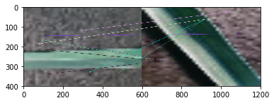

```python
sift(X_train[0], X_train[5])
```

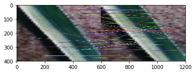

```python
sift(X_train[2], X_train[5])
```

Sometimes, like these two example, the results are fine. It could match some parts of the plants and some parts of the background. And when comparing two images that have really similar part, the result is very good.

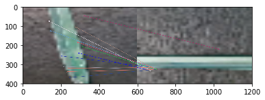

```python
sift(X_train[22], X_train[3])
```

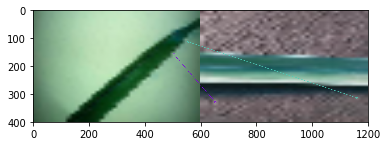

```python
sift(X_train[25], X_train[32])
```